# **ESM 244 Advanced Data Analysis HW1 Part 1**

Yirui Zhang

### Data wrangling & visualization

The California Communities Environmental Health Screening Tool (CalEnviroScreen) is a tool that helps identify vulunterable communities that are most affected by pollution. CalEnviroScreen combines 19 indicators, broken into three categories: pollution burdens, socioeconomic indicators, and public health indicators. This project aims to assess the impact of race on CalEnviroScreen Score by analyzing the racial make up of CalEnviroScreen score. The data were obtained from CalEnviroScreen (version 3.0).

```r
#Load CES Race Data
dem_clean <- read.csv("Demo2.csv")
dem_clean2 <- dem_clean %>%
  clean_names()

#New dataset of scores from different races using Group_By and Summarize function
dem_set <- dem_clean2 %>%
  group_by(percentile) %>%
  summarize(Hispanic = mean(hispanic, round(2)),
            White = mean(white, round(2)),
            Asian = mean(asian_american, round(2)),
            native = mean (native_american, round(2)),
            africa = mean (african_american, round(2)),
            Other = mean(other, round(2))) %>%
   na.omit()#omit any NA variables

#Update colomum names from the new dataset
names(dem_set)[names(dem_set) == "africa"] <- "African American"
names(dem_set)[names(dem_set) == "native"] <- "Native American"
```

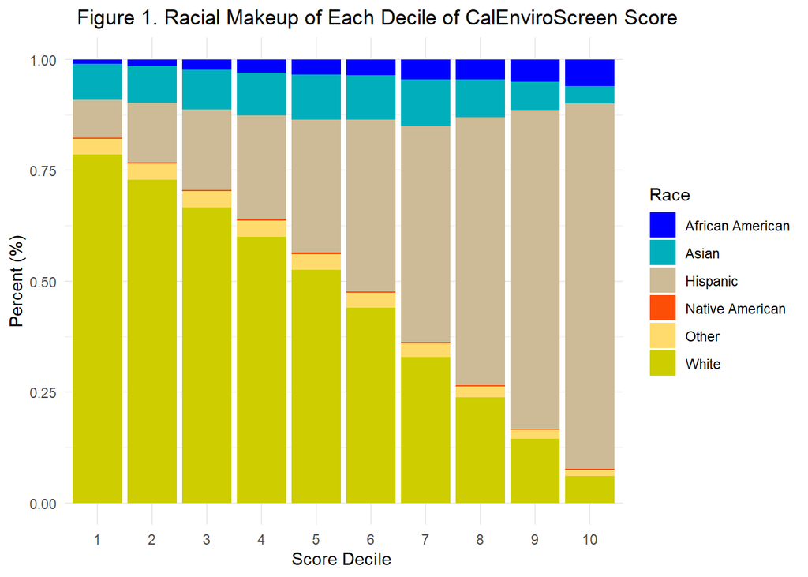

```r
dem_tidy <- gather(dem_set, "race","Race_Percent","White", "Hispanic", "Asian", "Native American","African American","Other" )
#dem_tidy <- na.omit(dem_tidy)

dem_tidy_test <- dem_tidy %>%
  mutate(Percentile = factor(percentile, levels = c("1","2","3","4","5","6","7","8","9", "10")))

#Make the plot of racial makeup of CalEnviroScreen score
test <- ggplot (dem_tidy_test, aes(x=Percentile, y = Race_Percent, fill = race))+
  #show the components of each decile of score
  geom_bar(stat = "identity", position = "fill")+
  #Add title
  ggtitle ("  Figure 1. Racial Makeup of Each Decile of CalEnviroScreen Score ")+
  #Add x/y axis
  labs(y="Percent (%)", x = "Score Decile ", fill = "Race")+
  #Choosing colors for each race category
  scale_fill_manual(values = c("blue","#00AFBB", "wheat3", "#FC4E07","#FFDB6D","yellow3"))+
  #Adjust the position of capition
  theme(plot.caption = element_text(hjust = 0))+
  #Select themes and background
  theme_minimal()

test
```

**Figure 1. Racial make up of Each Decile of CalEnviroScreen Score.** The x-axis is the decile of CalEnviroScreen score and a higher score means a higher pollution and health impact. (Data Source: Office of Environmental Health Hazard Assessment (OEHHA). 2017. CalEnviroScreen 3.0)

Figure 1 shows how people of color are over-represented in ten percent increments of CalEnviroScreen. A higher CalEnvioScreen score is associated with higher Hispanic and African American population percentage, and a lower white population percent. That is being said, Hispanic and African Americans disproportionately reside in highly impacted communities, while white people reside in least impacted communities.

```r
#Edit Column name of dataset
names(dem_set)[names(dem_set) == "percentile"] <- "Score Decile"
names(dem_set)[names(dem_set) == "Hispanic"] <- "Hispanic (%)"
names(dem_set)[names(dem_set) == "White"] <- "White (%)"
names(dem_set)[names(dem_set) == "Native American"] <- "Native American (%)"
names(dem_set)[names(dem_set) == "Asian"] <- "Asian American (%)"
names(dem_set)[names(dem_set) == "African American"] <- "African American (%)"
names(dem_set)[names(dem_set) == "Other"] <- "Other Race (%)"

#Make a Table
Table <- dem_set %>%
  #Add caption
  kable() %>%
  #Format the table
  column_spec(1, bold = T, color = "blue", background = "grey55") %>%
  kable_styling(bootstrap_options = c("hover", position = "center",row_label_position = "c", font_size = 14))
Table
```

| Score Decile | Hispanic (%) | White (%) | Asian American (%) | Native American (%) | African American (%) | Other Race (%) |
| --- | --- | --- | --- | --- | --- | --- |
| 1 | 8.3 | 76.3 | 7.9 | 0.2 | 1.0 | 3.4 |
| 2 | 12.6 | 68.5 | 7.8 | 0.3 | 1.4 | 3.4 |
| 3 | 16.6 | 60.9 | 8.2 | 0.3 | 2.1 | 3.4 |
| 4 | 21.1 | 54.0 | 8.7 | 0.3 | 2.7 | 3.3 |
| 5 | 26.5 | 46.4 | 9.0 | 0.3 | 3.0 | 3.1 |
| 6 | 33.8 | 38.4 | 8.8 | 0.3 | 3.1 | 2.9 |
| 7 | 40.2 | 27.2 | 8.7 | 0.3 | 3.7 | 2.5 |
| 8 | 52.5 | 20.7 | 7.5 | 0.3 | 3.9 | 2.1 |
| 9 | 63.1 | 12.7 | 5.6 | 0.2 | 4.4 | 1.7 |
| 10 | 72.6 | 5.3 | 3.4 | 0.2 | 5.3 | 1.2 |

**Table 1. Racial Makeup of Each Decile of CalEnviroScreen Score** This table indicates a similar association: Hispanic and African Americans population concentrated in highly impacted communities which have higher CalEnviroScreen scores, while majority population of the least impacted communitiesis white people. (Data Source: Office of Environmental Health Hazard Assessment (OEHHA). 2017. CalEnviroScreen 3.0.)